# Combination of Buffer and pixel sizes, plus fake points

[Index](https://valentinzarate.github.io/moon_sleeping_sites/) [Moon and Sleeping sites](https://valentinzarate.github.io/moon_sleeping_sites/moon_sleeping.html) [RSFs](https://valentinzarate.github.io/moon_sleeping_sites/rsf_moon.html)

## 1 Model Robustness and Spatial Structure

To ensure the reliability of our resource selection function, we evaluated whether model coefficients remain stable across multiple realizations of randomly generated available points ([Northup et al. (2022)](https://esajournals.onlinelibrary.wiley.com/doi/full/10.1002/eap.2470)). Coding is based on [Fieberg et al. (2021)](https://besjournals.onlinelibrary.wiley.com/doi/full/10.1111/1365-2656.13441) publication code. .

### 1.1 Why this matters

Available points are drawn stochastically within defined spatial buffers. This randomness can introduce variability in coefficient estimates. By comparing multiple runs (100 in this case), we assessed whether our main ecological inferences hold regardless of the specific random sample used.

### 1.2 Spatial autocorrelation in canopy height and NDVI

We also explored the spatial structure of two key predictors, canopy height and NDVI, since both are derived from remotely sensed data and are known to exhibit spatial autocorrelation. If left unaccounted for, spatial autocorrelation can inflate type I error rates and lead to spurious model performance.

### 1.3 Summary

These diagnostic steps allowed us to test the sensitivity of our results to sampling artifacts and spatial dependencies. Confirming coefficient stability and understanding the autocorrelation patterns of environmental predictors ensures that our conclusions about primate sleeping site selection are methodologically robust and ecologically meaningful.

## 2 Libraries

```r
library(tidyverse)
library(terra)
library(suncalc)
library(purrr)
library(hexbin)
library(broom.mixed)
library(lme4)
library(viridis)
library(geosphere)
library(scales)
library(spdep)
```

```r
moon <- readRDS("moon_base.rds")
```

### 2.1 Environmental Covariate Data Preparation

We prepared a set of high-resolution spatial datasets to characterize environmental conditions across all roost sites and their surroundings for subsequent analyses. **Canopy height** and its associated uncertainty were extracted from the 2020 ETH Global Canopy Height product at 10-m resolution (ETH Global Canopy Height 2020, S27W057; see Lang et al., 2022). These raster layers provide both mean canopy height and the associated standard deviation (canopy structural variability) for each grid cell.

**Weather data** were obtained from local meteorological records (“clima.csv”), including daily total precipitation (pp), maximum temperature (t_max), and minimum temperature (t_min), and were later merged with the main dataset by date.

These data sources were loaded into R as raster or tabular objects and provided the basis for extracting, by spatial overlay or table join, the corresponding environmental values at each roost or pseudo-absence location for every night included in the analysis.

**Canopy Height and Error**

```r
canopy <- rast("ETH_GlobalCanopyHeight_10m_2020_S27W057_Map.tif")
canopy_sd <- rast("ETH_GlobalCanopyHeight_10m_2020_S27W057_Map_SD.tif")
```

### **NDVI Raster Compilation**

This code block automatically compiles and prepares Sentinel-2 NDVI rasters for multiple dates from a directory of downloaded image files. The workflow ensures that each NDVI raster is properly calculated from its respective bands for later extraction and analysis.

- **File Listing and Information Extraction:**  
  Lists all Sentinel-2 `.jp2` files in the specified directory, then parses the filenames to extract acquisition dates and the band type (B04: red, B08: near-infrared).
- **Band Pairing:**  
  Filters and pairs files to ensure that both B04 and B08 bands exist for each image date, constructing a data frame (`bands_df`) with matching pairs.
- **NDVI Calculation Function:**  
  Defines a custom function that takes the file paths for the red (B04) and near-infrared (B08) bands, reads them as raster layers, and computes the NDVI using the standard formula: `(B08 - B04) / (B08 + B04)`.
- **Batch NDVI Calculation:**  
  Applies the NDVI calculation function to every row of `bands_df` using `purrr::map2`, resulting in a list column where each entry is a calculated NDVI raster for its corresponding date.

This approach enables efficient and reproducible NDVI preparation for large numbers of satellite scenes, providing a ready-to-use table (`bands_df`) for spatial extraction and temporal matching in subsequent ecological analyses.

```r
files <- list.files("ndvi", pattern = "\\.jp2$", full.names = TRUE)
info <- tibble(
  file = files,
  name = basename(files)
) %>%
  mutate(
    date_chr = str_extract(name, "\\d{8}T\\d{6}"),
    date = ymd_hms(str_sub(date_chr, 1, 8) %>% paste0(" ", str_sub(date_chr, 10, 15) %>% str_replace("T", ""))),
    band = str_extract(name, "B\\d{2}")
  )

bands_df <- info %>%
  filter(band %in% c("B04", "B08")) %>%
  select(date, band, file) %>%
  tidyr::pivot_wider(names_from = band, values_from = file)

bands_df <- bands_df %>% filter(!is.na(B04) & !is.na(B08))

calc_ndvi <- function(b04_path, b08_path) {
  b04 <- rast(b04_path)
  b08 <- rast(b08_path)
  ndvi <- (b08 - b04) / (b08 + b04)
  ndvi
}

bands_df <- bands_df %>%
  mutate(ndvi = map2(B04, B08, calc_ndvi))
```

**Weather information**

```r
weather <- read.csv("clima.csv")
```

## 3 Random Points Combinations

This script implements a systematic approach to generate all combinations of buffer size and number of random (pseudo-absence) points around each roost (“used”) site, with the goal of optimizing the design of resource selection analyses. For each possible combination of number of random points (`n_fake`) and buffer radius, the following steps are executed:

- **Random point generation:** For each observed roost site and night, `n_fake` random points are generated at random bearings (0–360°) and random distances (uniformly distributed between a minimum and maximum buffer distance) from the observed roost location. A minimum distance (`min_dist`) is enforced between all random points generated for the same night to reduce spatial clustering.
- **Data merging:** All “used” (real) points and the newly generated “available” (random) points are combined into a single dataset, with all points from the same group and night assigned a unique event identifier.
- **Parameter tracking:** Each point is annotated with the buffer size and number of random points used for its generation, enabling downstream comparisons across design choices.
- **List storage:** The resulting dataset for each combination is stored as a separate element in a list for easy iteration and analysis.

This approach is fully automated, enabling rapid testing of all pairwise combinations of six candidate numbers of random points and five buffer sizes (30 total combinations).

### 3.1 Rationale

We systematically explored all parameter combinations in order to balance two methodological goals:  
(i) minimizing spatial autocorrelation between “used” and “available” points (which can arise if random points are placed too close together or too close to the used location), and  
(ii) maximizing stability and robustness of estimated coefficients in RSF (Resource Selection Function) models, given the inherent stochasticity in random point generation.

By storing the full set of possible design permutations, we were able to quantify how variation in random point number and buffer size affects both spatial structure in the data and model outcomes, and to select optimal parameter values for final inference. This design ensures transparent, reproducible, and robust ecological modeling.

```r
n_fakes <- c(1, 2, 5, 10, 15, 20)
buffers <- c(100, 200, 300, 400, 500)
min_dist <- 30

combos <- expand.grid(n_fake = n_fakes, buffer = buffers)

set.seed(42)

all_dfs <- list()

for (i in 1:nrow(combos)) {
  n_fake <- combos$n_fake[i]
  buffer <- combos$buffer[i]
  message("Combinando: ", n_fake, " puntos, buffer: ", buffer)

  pseudo_data <- moon %>%
    rowwise() %>%
    do({
      res <- generate_pseudo_points(
        lat = .$lat, lon = .$lon,
        n_fake = n_fake, buffer = buffer, min_dist = min_dist,
        fecha = .$fecha,
        group = .$group,
        moon_fraction = .$moon_fraction,
        moon_phase_angle = .$moon_phase_angle,
        moon_phase_name = .$moon_phase_name,
        moon_visible = .$moon_visible,
        used = FALSE
      )
      if (is.null(res)) tibble(
        lon = numeric(0), lat = numeric(0),
        fecha = character(0), group = character(0),
        moon_fraction = numeric(0), moon_phase_angle = numeric(0),
        moon_phase_name = character(0), moon_visible = logical(0),
        used = logical(0)
      )
      else res
    }) %>%
    ungroup() %>%
    mutate(n_fake = n_fake, buffer = buffer)

  moon_used <- moon %>%
    mutate(used = TRUE,
           n_fake = n_fake,
           buffer = buffer) %>%
    select(lon, lat, fecha, group, moon_fraction, moon_phase_angle,
           moon_phase_name, moon_visible, used, n_fake, buffer)

  moon_all <- bind_rows(moon_used, pseudo_data)

  moon_all <- moon_all %>%
    mutate(event_key = paste(group, fecha, sep = "_")) %>%
    group_by(event_key) %>%
    mutate(id = cur_group_id()) %>%
    ungroup() %>%
    select(-event_key)

  all_dfs[[paste0("n", n_fake, "_b", buffer)]] <- moon_all
}
```

## 4 Moonlight and Canopy

We defined dedicated R functions to systematically annotate each point in our datasets with key environmental covariates required for our analyses:

### 4.1 Function: `agregar_moon_luz()`

This function calculates temporally- and spatially-explicit lunar illumination indices for each point. For every location, it:

- Computes three timestamps for the same night: the previous evening (20:00), local midnight (00:00), and early morning (04:00), relative to the recorded date.
- Uses these timestamps and the point’s coordinates to determine the altitude of the moon above the horizon at each time, via the `getMoonPosition()` function.
- For each time, calculates the scaled altitude as the sine of the moon’s altitude (with values below zero set to zero, reflecting the moon being below the horizon).
- Computes an average scaled moon altitude for the night, and multiplies this by the moon’s illuminated fraction to yield an “effective moonlight” index for each site-night.
- Returns the original data frame with two additional columns: average moon altitude and effective moonlight index.

These steps ensure that the model incorporates realistic, time-specific measures of nocturnal lunar illumination at each site, which is ecologically relevant for species with night-time activity.

### 4.2 Function: `agregar_canopy()`

This function extracts canopy structure variables for each point, by:

- Converting each point’s coordinates into a spatial vector with the appropriate coordinate reference system (CRS) for raster extraction.
- Extracting the mean canopy height and the associated standard deviation (as a measure of canopy structural variability) from high-resolution raster layers at each point’s location.
- Appending these values as new columns to the input data frame.

By using these functions in sequence, we consistently enrich each observation with the relevant spatially- and temporally-matched environmental predictors needed for robust resource selection modeling.

```r
agregar_moon_luz <- function(df) {
  df <- df %>%
    mutate(
      fecha_a = as.POSIXct(paste(as.Date(fecha) - 1, "20:00:00"), tz = "UTC"),
      fecha_b = as.POSIXct(paste(as.Date(fecha), "00:00:00"), tz = "UTC"),
      fecha_c = as.POSIXct(paste(as.Date(fecha), "04:00:00"), tz = "UTC")
    )

  pos_a <- getMoonPosition(data = df %>% rename(date = fecha_a) %>% select(date, lat, lon))
  pos_b <- getMoonPosition(data = df %>% rename(date = fecha_b) %>% select(date, lat, lon))
  pos_c <- getMoonPosition(data = df %>% rename(date = fecha_c) %>% select(date, lat, lon))

  alt_scaled_a <- pmax(0, sin(pos_a$altitude))
  alt_scaled_b <- pmax(0, sin(pos_b$altitude))
  alt_scaled_c <- pmax(0, sin(pos_c$altitude))

  df <- df %>%
    mutate(
      moon_altitude_avg = (alt_scaled_a + alt_scaled_b + alt_scaled_c) / 3,
      moon_light_effective_avg = moon_fraction * moon_altitude_avg
    )
  return(df)
}

agregar_canopy <- function(df, canopy, canopy_sd) {
  moon_vect <- vect(df, geom = c("lon", "lat"), crs = crs(canopy))
  df$canopy_height <- extract(canopy, moon_vect)[,2]
  df$canopy_height_sd <- extract(canopy_sd, moon_vect)[,2]
  df <- df[df$canopy_height_sd <= 6, ]
  return(df)
}
```

```r
all_dfs_proc <- map(
  all_dfs,
  ~ .x %>%
    agregar_moon_luz() %>%
    agregar_canopy(canopy, canopy_sd))
```

Lets see this visually

```r
comb_names <- c(
  "n1_b100",
  "n2_b200",
  "n5_b300",
  "n10_b400",
  "n15_b500",
  "n20_b500")
```

```r
plot_df <- purrr::map_dfr(
  comb_names,
  ~ dplyr::mutate(all_dfs_proc[[.x]], combination = .x)
)
plot_df$used <- as.factor(plot_df$used)
```

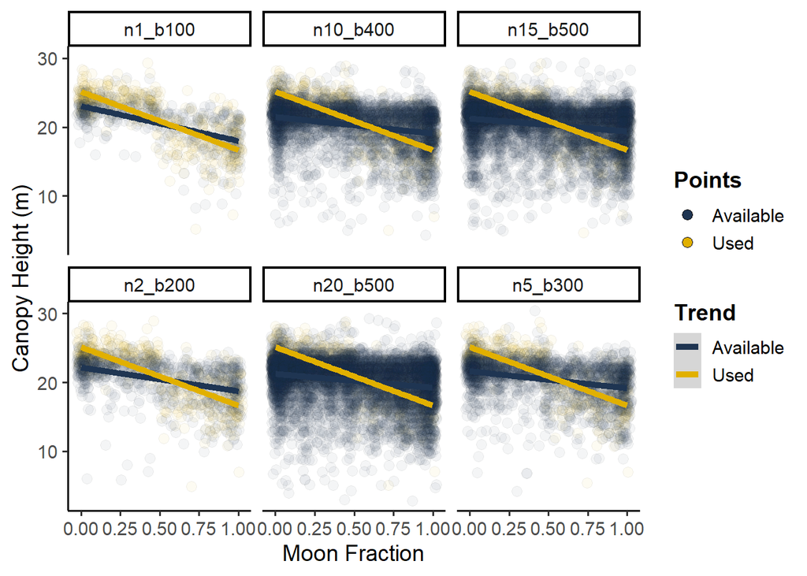

```r
ggplot(plot_df, aes(x = moon_fraction, y = canopy_height)) +
  geom_jitter(
    aes(fill = used),
    shape = 21, size = 3, stroke = 0.3,
    alpha = 0.05, color = "black",
    width = 0.03,
    show.legend = TRUE
  ) +
  geom_smooth(
    aes(color = used),
    method = "lm",
    se = TRUE,
    size = 1.9
  ) +
  scale_fill_manual(
    values = c("TRUE" = "#E1B000", "FALSE" = "#1F3552"),
    labels = c("Available", "Used"),
    name = "Points"
  ) +
  scale_color_manual(
    values = c("TRUE" = "#E1B000", "FALSE" = "#1F3552"),
    labels = c("Available", "Used"),
    name = "Trend"
  ) +
  guides(
    fill = guide_legend(override.aes = list(alpha = 1)),
    color = guide_legend(override.aes = list(size = 1.5))
  ) +
  labs(
    x = "Moon Fraction",
    y = "Canopy Height (m)"
  ) +
  facet_wrap(~ combination, nrow = 2) +
  theme_classic(base_size = 14) +
  theme(
    plot.title = element_text(size = 15, face = "bold"),
    axis.title = element_text(),
    legend.title = element_text(face = "bold"),
    legend.position = "right"
  )
```

**Function: agregar_ndvi_flexible()**

This function assigns a satellite-derived NDVI (Normalized Difference Vegetation Index) value to each observation point in a data frame, based on the closest available Sentinel-2 image in time. The workflow is fully flexible and can handle any number of NDVI images and observation points.

For each observation, the function:

Identifies the Closest NDVI Date: For each row’s timestamp, the function searches a precompiled table of NDVI rasters and selects the one with the date nearest to the observation (minimizing the temporal gap).

Calculates Spatial Extraction: Each observation’s coordinates (longitude and latitude) are converted into a spatial object, reprojected if necessary to match the coordinate reference system (CRS) of the NDVI raster, and the NDVI value is extracted at that location.

Assigns NDVI Value: The extracted NDVI value is added as a new column (ndvi_sentinel) in the data frame, characterizing the vegetation productivity at each point using the most relevant satellite image.

Returns the Updated Data Frame: The result is a data frame where every observation is annotated with its corresponding NDVI value, ensuring each point is accurately linked to the best available vegetation metric.

**Why use this approach?** Unlike seasonal or fixed-date matching, this flexible method ensures that each observation receives an NDVI value from the closest possible satellite acquisition date, accommodating uneven satellite coverage and optimizing ecological relevance for analyses such as habitat modeling or resource selection.

```r
agregar_ndvi_flexible <- function(df, bands_df) {
  df <- df %>%
    mutate(fecha = as.POSIXct(fecha))
  df$ndvi_sentinel <- NA_real_

  for (i in seq_len(nrow(df))) {
    this_pt <- df[i, ]
    idx_nearest <- which.min(abs(difftime(this_pt$fecha, bands_df$date, units = "secs")))
    ndvi_rast <- bands_df$ndvi[[idx_nearest]]

    pt_vect <- vect(this_pt, geom = c("lon", "lat"), crs = "EPSG:4326") %>%
      project(crs(ndvi_rast))

    ndvi_val <- terra::extract(ndvi_rast, pt_vect)[, 2]
    df$ndvi_sentinel[i] <- ndvi_val
  }
  return(df)
}
```

```r
all_dfs_proc <- map(
  all_dfs_proc,
  ~ agregar_ndvi_flexible(.x, bands_df)
)
```

### 4.3 Function: `add_weather_vars()`

This function appends daily weather variables—precipitation (pp), maximum temperature (t_max), and minimum temperature (t_min), to each point by joining on the observation date.  
It ensures that each “used” and “available” point is annotated with the relevant weather conditions for its respective night.

```r
add_weather_vars <- function(df, weather) {
  df <- df %>%
    left_join(weather %>% select(fecha, pp),    by = "fecha") %>%
    left_join(weather %>% select(fecha, t_max), by = "fecha") %>%
    left_join(weather %>% select(fecha, t_min), by = "fecha")
  return(df)
}
```

```r
all_dfs_proc <- map(
  all_dfs_proc,
  ~ add_weather_vars(.x, weather)
)
```

```r
comb_names <- c("n1_b100", "n2_b200", "n5_b300", "n10_b400", "n15_b500", "n20_b500")
```

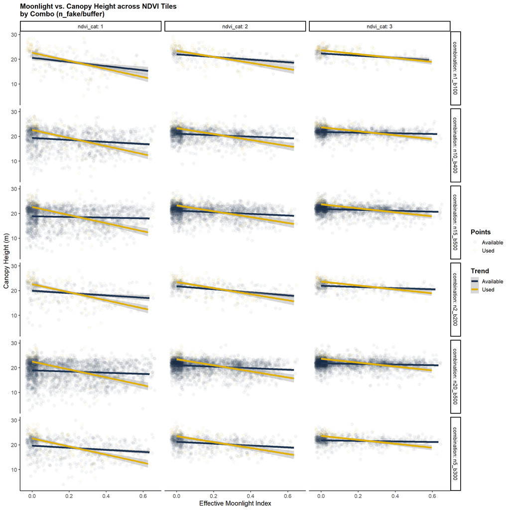

```r
plot_df <- map_dfr(
  comb_names,
  ~ all_dfs_proc[[.x]] %>%
      mutate(ndvi_cat = ntile(ndvi_sentinel, 3),
             combination = .x)
)
plot_df$used <- as.factor(plot_df$used)

ggplot(plot_df, aes(x = moon_light_effective_avg, y = canopy_height)) +
  geom_jitter(
    aes(fill = used),
    shape = 21, size = 3, stroke = 0.3,
    alpha = 0.05, color = "black",
    width = 0.03,
    show.legend = TRUE
  ) +
  geom_smooth(
    aes(color = used),
    method = "lm",
    se = TRUE,
    size = 1.9
  ) +
  facet_grid(combination ~ ndvi_cat, labeller = label_both) +
  scale_fill_manual(
    values = c("TRUE" = "#E1B000", "FALSE" = "#1F3552"),
    labels = c("Available", "Used"),
    name = "Points"
  ) +
  scale_color_manual(
    values = c("TRUE" = "#E1B000", "FALSE" = "#1F3552"),
    labels = c("Available", "Used"),
    name = "Trend"
  ) +
  labs(
    title = "Moonlight vs. Canopy Height across NDVI Tiles\nby Combo (n_fake/buffer)",
    x = "Effective Moonlight Index",
    y = "Canopy Height (m)"
  ) +
  theme_classic(base_size = 14) +
  theme(
    plot.title = element_text(size = 15, face = "bold"),
    axis.title = element_text(),
    legend.title = element_text(face = "bold"),
    legend.position = "right"
  )
```

## 5 Spatial Autocorrelation

### 5.1 Function: `calc_moran()` and Moran’s I Analysis Pipeline

The function `calc_moran()` quantifies spatial autocorrelation in canopy height across all locations within a given dataset using Moran’s I statistic. Specifically:

This function is applied iteratively across all combinations of randomization scenarios (`all_dfs_proc`), automatically extracting the number of random points (`n_fake`) and buffer size from each dataset’s identifier. The results are consolidated in a single summary table (`moran_table`), allowing comparison of spatial autocorrelation across all parameter combinations.

### 5.2 Spatial Autocorrelation Analysis Using Moran’s I

**Interpretation:**  
- A high, positive Moran’s I value indicates that points with similar canopy height tend to be spatially clustered (high autocorrelation). - A value near zero suggests little to no spatial structure (randomness). - A negative value implies spatial dispersion (points with dissimilar values are close together).

**Purpose in the study:**  
This analysis allows us to systematically assess how different randomization designs (i.e., number of pseudo-absence points and buffer size) affect the spatial autocorrelation present in our environmental covariate data. By minimizing spatial autocorrelation in the generated points, we reduce the risk of statistical biases and improve the robustness of subsequent resource selection analyses (RSF). The Moran’s I table provides an empirical basis for selecting optimal parameter values for generating pseudo-absence points.

```r
df <- all_dfs_proc[[1]]
sum(is.na(df$lon) | is.na(df$lat))
sum(is.na(df$canopy_height))

coords <- as.matrix(df[, c("lon", "lat")])
dlist <- dnearneigh(coords, 0, 0.01, longlat = TRUE)
table(card(dlist))
```

[output not shown]

```r
calc_moran <- function(df) {
  df <- df[!is.na(df$canopy_height) & !is.na(df$lon) & !is.na(df$lat), ]
  if(nrow(df) < 10) return(data.frame(moran_i=NA, pval=NA))
  if(nrow(df) > 500) df <- df[sample(1:nrow(df), 500), ]
  coords <- as.matrix(df[, c("lon", "lat")])

  dlist <- dnearneigh(coords, 0, 0.002, longlat = TRUE)
  if(any(card(dlist)==0)) {
    dlist <- dnearneigh(coords, 0, 0.005, longlat = TRUE)
  }
  if(any(card(dlist)==0)) {
    dlist <- dnearneigh(coords, 0, 0.01, longlat = TRUE)
  }
  if(any(card(dlist)==0)) {
    dlist <- knn2nb(knearneigh(coords, k=8))
  }
  if(any(card(dlist)==0)) return(data.frame(moran_i=NA, pval=NA))

  lw <- nb2listw(dlist, style = "W", zero.policy = TRUE)
  res <- moran.test(df$canopy_height, lw, zero.policy = TRUE)
  moran_i <- res$estimate[1]
  pval <- res$p.value
  data.frame(moran_i = as.numeric(moran_i), pval = as.numeric(pval))
}


moran_table <- imap_dfr(
  all_dfs_proc,
  function(df, nm) {
    n_fake <- as.numeric(sub("n([0-9]+)_b[0-9]+", "\\1", nm))
    buffer <- as.numeric(sub("n[0-9]+_b([0-9]+)", "\\1", nm))
    moran_res <- tryCatch(calc_moran(df), error=function(e) data.frame(moran_i=NA, pval=NA))
    data.frame(
      combo = nm,
      n_fake = n_fake,
      buffer = buffer,
      moran_i = moran_res$moran_i,
      pval = moran_res$pval
    )
  }
)
```

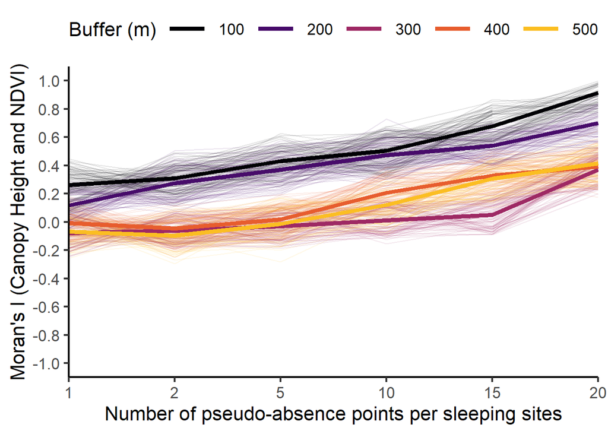

```r
moran_plot<-
  ggplot() +
  geom_line(
    data = simu_table,
    aes(x = factor(n_fake), y = moran_i_simu, group = interaction(buffer, rep), color = factor(buffer)),
    size = 0.4, alpha = 0.11
  ) +
  geom_line(
    data = media_table,
    aes(x = factor(n_fake), y = moran_i, group = factor(buffer), color = factor(buffer)),
    size = 1.6, alpha = 1
  ) +
  scale_color_viridis_d(name = "Buffer (m)", option = "inferno", end = 0.85) +
  scale_y_continuous(limits = c(-1, 1), breaks = seq(-1, 1, 0.2)) +
  scale_x_discrete(
    limits = as.character(c(1, 2, 5, 10, 15, 20)),
    breaks = as.character(c(1, 2, 5, 10, 15, 20)),
    expand = c(0,0)) +
  labs(
    x = "Number of pseudo-absence points per sleeping sites",
    y = "Moran's I (Canopy Height and NDVI)"
  ) +
  theme_classic(base_size = 16) +
  theme(
    plot.title = element_text(size = 15, hjust = 0),
    axis.title = element_text(),
    axis.text = element_text(size = 13),
    legend.position = "top",
    legend.title = element_text(),
    legend.key.height = unit(0.7, "lines"),
    legend.key.width  = unit(2.5, "lines"))
moran_plot
```

```r
ggsave("moran_plot.png", moran_plot, dpi = 300, width = 9, height = 5.5)
```

This could took a almost a day and a half in my computer :(

```r
n_fake <- c(1, 2, 5, 10, 15, 20)
buffers <- c(100, 200, 300, 400, 500)
n_rep <- 100

combos <- expand.grid(n_fake = n_fake, buffer = buffers)

sens_results <- vector("list", nrow(combos))

for(i in 1:nrow(combos)) {
  n_pts <- combos$n_fake[i]
  buffer <- combos$buffer[i]
  message("Simulating for n_fake = ", n_pts, ", buffer = ", buffer)

  sens_results[[i]] <- map(1:n_rep, function(r) {
    df_sim <- genera_puntos_falsos(moon, n_fake = n_pts, buffer = buffer, min_dist = 30)

    moon_used <- moon %>% mutate(used = TRUE)
    moon_all <- bind_rows(moon_used, df_sim)

    n_used <- sum(moon_all$used == TRUE)
    n_avail <- sum(moon_all$used == FALSE)
    moon_all <- moon_all %>%
      mutate(w = ifelse(used, 1, n_used / n_avail))

    fit <- glmer(used ~ moon_light_sc * canopy_height_sc +
          moon_light_sc * ndvi_sc +
          pp_sc * ndvi_sc +
          t_max_sc * canopy_height_sc +
          (1 | group/fecha),
               data = moon_all,
               weights = w,
               family = binomial(link = "logit"))

    coefs <- tidy(fit) %>%
      filter(term %in% c("moon_light_effective_avg", "canopy_height",
                         "moon_light_effective_avg:canopy_height"))
    coefs$n_fake <- n_pts
    coefs$buffer <- buffer
    coefs$rep <- r
    coefs
  }) %>% bind_rows()
}

all_sens <- bind_rows(sens_results)

sim_df <- all_sens %>%
  group_by(n_fake, buffer, term) %>%
  summarise(
    mean_est = mean(estimate, na.rm=TRUE),
    sd_est = sd(estimate, na.rm=TRUE),
    range_est = max(estimate, na.rm=TRUE) - min(estimate, na.rm=TRUE),
    mean_abs_diff = mean(abs(diff(sort(estimate))), na.rm=TRUE),
    .groups = "drop")
```

## 6 Sensitivity Analysis

To properly **account for the inherent randomness** involved in generating available (pseudo-absence) points for our RSF models, we performed a **sensitivity analysis** inspired by the approach of Fieberg et al. 2021 publication code

For **each combination** of buffer size and number of pseudo-absence points per roost, we repeated the random generation process **multiple times** (e.g., 100 replicates per scenario). For every replicate, we fitted a resource selection function (**RSF**) model that included the **interaction between moonlight availability and canopy height**.

We then extracted the coefficients of interest from each model fit and **summarized their variability** across replicates. This procedure allows us to directly quantify the uncertainty and stability of our RSF estimates, ensuring that our main conclusions are not driven by a particular random realization of available points.

**This sensitivity analysis is critical** because the spatial configuration of available points can influence both the magnitude and the significance of RSF coefficients. By systematically evaluating the spread and mean differences of coefficients across all randomizations, we can identify which parameter settings (buffer size and number of pseudo-absence points) yield the most robust and reliable inference.

Finally, the results of this sensitivity analysis will be **integrated with our assessment of spatial autocorrelation** (e.g., Moran’s I) to select the optimal pseudo-absence design for robust and unbiased ecological inference.

## 7 Optimal buffer and pseudo-absences

Balancing Buffer Size, Number of Pseudo-Absences, Sensitivity, and Spatial Autocorrelation

Let $b$ denote the buffer size (in meters) and $n$ the number of pseudo-absence points generated around each used point.

### 7.1 1. Sensitivity of RSF Estimators

For each $(b, n)$ combination, we repeat the random sampling process $R$ times and fit a resource selection function (RSF) in each iteration, yielding $R$ estimated coefficients $\hat{\beta}_{b,n}^{(r)}$ for a parameter of interest (e.g., interaction between moonlight and canopy height):

$$\hat{\beta}_{b,n}^{(r)}, \quad r = 1, 2, \ldots, R$$

We then quantify the sensitivity (variability) of the estimator as:

Where $\overline{\beta}_{b,n}$ is the mean coefficient estimate for that combination.

### 7.2 2. Spatial Autocorrelation (Moran’s I)

For each combination, we calculate the spatial autocorrelation of a habitat covariate (e.g., canopy height) using Moran’s I statistic:

$$I_{b,n} = \frac{N}{W} \cdot \frac{ \sum_{i=1}^{N} \sum_{j=1}^{N} w_{ij}
(x_i - \overline{x})(x_j - \overline{x}) }
{ \sum_{i=1}^{N} (x_i - \overline{x})^2 }$$

where $x_i$ is the covariate value at location $i$, $\overline{x}$ is the mean value, $w_{ij}$ is the spatial weight between $i$ and $j$, $N$ is the total number of points, and $W = \sum_{i,j} w_{ij}$.

### 7.3 3. Objective: Joint Optimization

Our goal is to select $(b^*, n^*)$ such that:

- The sensitivity of the estimators is minimized (i.e., low $\mathrm{Var}_{b,n}$ or $\mathrm{MAD}_{b,n}$)
- The spatial autocorrelation is minimized (i.e., $I_{b,n} \approx 0$ and not significant)

Formally,

$$(b^*, n^*) = \arg\min_{b, n} \left\{ f\left( \mathrm{Var}_{b,n},
|I_{b,n}| \right) \right\}$$

where $f(\cdot)$ is a function that balances estimator variability and spatial autocorrelation.

This joint optimization ensures that our RSF inferences are both **stable to the random generation of available points** and **free from spatial artifacts**.

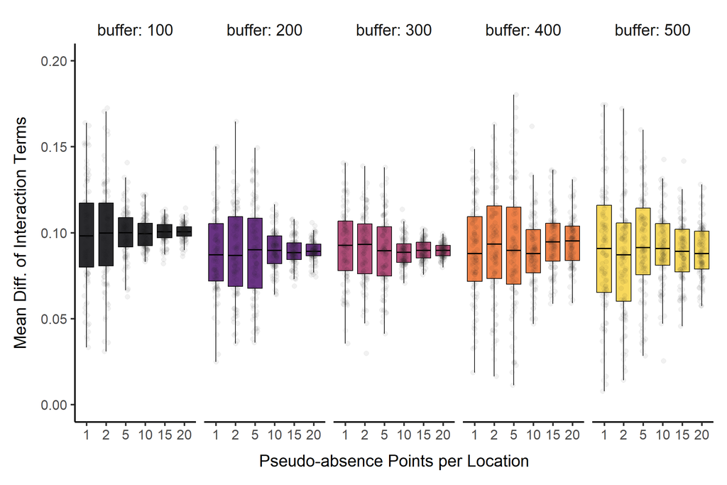

Distribution of RSF interaction estimator values (moonlight × canopy height, moonlight × NDVI, canopy height × max. temperature, NDVI × precipitations) for different numbers of pseudo-absence points and buffer sizes. Each boxplot represents the distribution of estimator values across simulations, and its size represent de mean absolute difference (mean diff.) in estimator values, smaller boxes indicate greater estimator stability).

```r
sensitivity_plot <-
  ggplot(sim_df, aes(x = factor(n_fake), y = estimate, fill = factor(buffer))) +
  geom_boxplot(
    outlier.shape = NA, width = 0.75, size = 0.4, alpha = 0.84, color = "black"
  ) +
  geom_jitter(
    width = 0.13, size = 2.4, alpha = 0.06, color = "grey9"
  ) +
  facet_grid(. ~ buffer, labeller = label_both) +
  scale_fill_viridis_d(option = "inferno", name = "Buffer (m)", end = 0.89) +
  scale_y_continuous(limits = c(0, 0.2)) +
  labs(
    x = "Pseudo-absence Points per Location",
    y = "Mean Diff. of Interaction Terms"
  ) +
  theme_classic(base_size = 20) +
  theme(
    plot.margin = margin(18, 16, 18, 16),
    strip.background = element_blank(),
    strip.text.x = element_text(size = 19),
    axis.title.x = element_text(margin = margin(t = 14)),
    axis.title.y = element_text(margin = margin(r = 14)),
    axis.title = element_text(),
    legend.position = "none")
sensitivity_plot
```

```r
ggsave("sens_plot.png", sensitivity_plot, dpi = 300, width = 11, height = 6)
```

```r
sim_summary <- mad_table %>%
  rename(mean_diff = mean_diff) %>%
  mutate(n_fake = as.numeric(as.character(n_fake)))

moran_summary <- media_table %>%
  select(buffer, n_fake, moran_i) %>%
  mutate(n_fake = as.numeric(as.character(n_fake)))
```

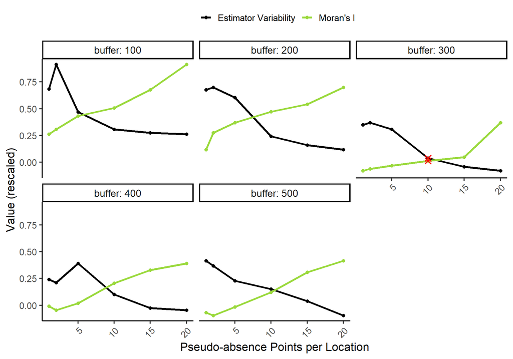

```r
balance_df <- left_join(sim_summary, moran_summary, by = c("buffer", "n_fake")) %>%
  group_by(buffer) %>%
  mutate(mean_diff_rescaled = scales::rescale(mean_diff, to = range(moran_i, na.rm = TRUE))) %>%
  ungroup()

balance_long <- balance_df %>%
  pivot_longer(
    cols = c(mean_diff_rescaled, moran_i),
    names_to = "metric",
    values_to = "value"
  ) %>%
  mutate(metric = recode(metric,
                         mean_diff_rescaled = "Estimator Variability",
                         moran_i = "Moran's I"))

highlight_300 <- balance_df %>%
  filter(buffer == 300, n_fake == 10) %>%
  pivot_longer(
    cols = c(mean_diff_rescaled, moran_i),
    names_to = "metric",
    values_to = "value"
  ) %>%
  mutate(metric = recode(metric,
                         mean_diff_rescaled = "Estimator Variability",
                         moran_i = "Moran's I"))

balance_plot <-
  ggplot(balance_long, aes(x = n_fake, y = value, group = metric, color = metric)) +
  geom_line(size = 1.4) +
  geom_point(size = 2) +
  facet_wrap(~ buffer, labeller = label_both) +
  scale_color_manual(
    name = "",
    values = c("Estimator Variability" = "black", "Moran's I" = viridis(2, end = 0.85)[2])
  ) +
  geom_point(
    data = highlight_300,
    aes(x = n_fake, y = value),
    color = "red", size = 3, shape = 4, stroke = 1.3,  inherit.aes = FALSE
  ) +
  labs(
    x = "Pseudo-absence Points per Location",
    y = "Value (rescaled)"
  ) +
  theme_classic(base_size = 16) +
  theme(
    legend.position = "top",
    legend.title = element_text(),
    axis.title = element_text(),
    axis.text.x = element_text(angle = 45, hjust = 1),
    strip.text = element_text(size = 14))
balance_plot
```

```r
ggsave("balance_plot.png", balance_plot, dpi = 300, width = 10, height = 6)
```